# Decision Trees

- Name: Martin Skarzynski
- Twitter: marskar
- GitHub: marskar
- Website: marskar.github.io

```python
import datetime
datetime.datetime.today().strftime("%B %d, %Y")
```

```
'July 17, 2019'
```

## Learning Objectives

Students will be able to:

- Explain how a decision tree is created.
- Build a decision tree model in scikit-learn.
- Tune a decision tree model and explain how tuning impacts the model.
- Interpret a tree diagram.
- Describe the key differences between regression and classification trees.
- Decide whether or not a decision tree is an appropriate model for a given problem.

### Why are we learning about decision trees?

- Easy to explain to others (interpretable).
- Very popular among data scientists.
- Form the basis for more sophisticated models.
- Have a different way of "thinking" than the other models (non-linear, non-parametric).
- Can be applied to both regression and classification problems.

[figure not shown]

### Decision tree

[figure not shown]

### Decision tree levels

[figure not shown]

### Decision tree overfitting

[figure not shown]

## What Happens When We Grow a Tree Too Deep?

Baseball player salary example:

- **On the left:** A regression tree for salary that is **grown deeper**.
- **On the right:** A comparison of the **training, testing, and cross-validation errors** for trees with different numbers of leaves.

[figure not shown]

### Decision tree evaluation

[figure not shown]

### Summary: Comparing Decision Trees With Other Models

**Advantages of decision trees:**

- They can be used for regression or classification.
- They can be displayed graphically.
- They are highly interpretable.
- They can be specified as a series of rules, and more closely approximate human decision-making than other models.
- Their features don't need scaling.
- They automatically learn feature interactions.
- Tends to ignore irrelevant features.
- They are non-parametric (i.e. will outperform linear models if the relationship between features and response is highly non-linear).

**Disadvantages of decision trees:**

- **Prone to overfitting:** They can easily overfit the training data (tuning is required).
- **High variance**: Small variations in the data can result in a completely different tree.
- **Greedy:** Recursive binary splitting makes "locally optimal" decisions that may not result in a globally optimal tree.
- **Sensitive to class imbalance:** They don't tend to work well if the classes are highly unbalanced.
- **Need big data:** They don't tend to work well with very small data sets.

### Ensemble models

Decision trees are typically used as a **building block** for other more sophisticated models. These sophisticated models are actually very cutting-edge, and solve *all* of the aforementioned problems.

### Fit a decision tree model with `scikit-learn`

```python
### Load packages
from sklearn.datasets import load_breast_cancer
import pandas as pd
import matplotlib.pyplot as plt
import seaborn as sns
import numpy as np
import pydotplus
from sklearn import tree, metrics, model_selection, preprocessing
from sklearn.metrics import confusion_matrix
from IPython.display import Image, display
%matplotlib inline
```

```python
### Load data
bc = load_breast_cancer()
```

```python
### Create dataframe
df = pd.DataFrame(bc.data, columns=bc.feature_names)
df['target'] = bc.target
df['Label'] = df.target.replace(0, 'malignant').replace(1, 'benign')
```

### Exploratory data analysis

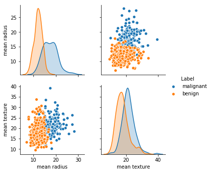

```python
# Plot the first 2 variables separated by label
sns.pairplot(df, vars=bc.feature_names[:2], hue='Label')
plt.savefig('img/scatter_matrix.png', dpi=300)
```

```python
# Obtain counts of each target (label)
from numpy import bincount
bincount(bc.target)
```

```
array([212, 357])
```

```python
# Look at target (label) names
bc.target_names
```

```
array(['malignant', 'benign'], dtype='<U9')
```

```python
# Print the dataset description
print(bc.DESCR)
```

```
.. _breast_cancer_dataset:

Breast cancer wisconsin (diagnostic) dataset
--------------------------------------------

**Data Set Characteristics:**

    :Number of Instances: 569

    :Number of Attributes: 30 numeric, predictive attributes and the class

    :Attribute Information:
        - radius (mean of distances from center to points on the perimeter)
        - texture (standard deviation of gray-scale values)
        - perimeter
        - area
        - smoothness (local variation in radius lengths)
        - compactness (perimeter^2 / area - 1.0)
        - concavity (severity of concave portions of the contour)
        - concave points (number of concave portions of the contour)
        - symmetry
        - fractal dimension ("coastline approximation" - 1)

        The mean, standard error, and "worst" or largest (mean of the three
        largest values) of these features were computed for each image,
        resulting in 30 features.  For instance, field 3 is Mean Radius, field
        13 is Radius SE, field 23 is Worst Radius.

        - class:
                - WDBC-Malignant
                - WDBC-Benign

    :Summary Statistics:

    ===================================== ====== ======
                                           Min    Max
    ===================================== ====== ======
    radius (mean):                        6.981  28.11
    texture (mean):                       9.71   39.28
    perimeter (mean):                     43.79  188.5
```

[output cut: 63 more lines]

```
ftp ftp.cs.wisc.edu
cd math-prog/cpo-dataset/machine-learn/WDBC/

.. topic:: References

   - W.N. Street, W.H. Wolberg and O.L. Mangasarian. Nuclear feature extraction
     for breast tumor diagnosis. IS&T/SPIE 1993 International Symposium on
     Electronic Imaging: Science and Technology, volume 1905, pages 861-870,
     San Jose, CA, 1993.
   - O.L. Mangasarian, W.N. Street and W.H. Wolberg. Breast cancer diagnosis and
     prognosis via linear programming. Operations Research, 43(4), pages 570-577,
     July-August 1995.
   - W.H. Wolberg, W.N. Street, and O.L. Mangasarian. Machine learning techniques
     to diagnose breast cancer from fine-needle aspirates. Cancer Letters 77 (1994)
     163-171.
```

```python
# Split data randomly into 70% training and 30% test
X = bc.data
y = bc.target
X_train, X_test, y_train, y_test = model_selection.train_test_split(X, y, test_size=0.3, random_state=0)
```

```python
# Train the decision tree
dtree = tree.DecisionTreeClassifier(criterion='gini', max_depth=2, random_state=0)
dtree.fit(X_train, y_train)
```

```
DecisionTreeClassifier(class_weight=None, criterion='gini', max_depth=2,
            max_features=None, max_leaf_nodes=None,
            min_impurity_decrease=0.0, min_impurity_split=None,
            min_samples_leaf=1, min_samples_split=2,
            min_weight_fraction_leaf=0.0, presort=False, random_state=0,
            splitter='best')
```

```python
# Use the model to make predictions with the test data
y_pred = dtree.predict(X_test)
```

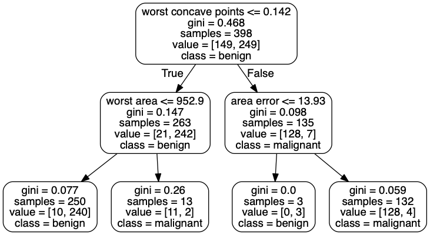

```
True
```

```python
# Visualize the decision tree
dot_data = tree.export_graphviz(dtree, out_file=None, filled=False, rounded=True,
                                feature_names=bc.feature_names,
                                class_names=bc.target_names)
graph = pydotplus.graph_from_dot_data(dot_data)
display(Image(graph.create_png()))

graph.write_png('img/tree.png')
```

```python
# How did our model perform?
count_misclassified = (y_test != y_pred).sum()
print('Misclassified samples: {}'.format(count_misclassified))
accuracy = metrics.accuracy_score(y_test, y_pred)
print('Accuracy: {:.2f}'.format(accuracy))
```

```
Misclassified samples: 9
Accuracy: 0.95
```

```python
sns.set(font_scale=3)
```

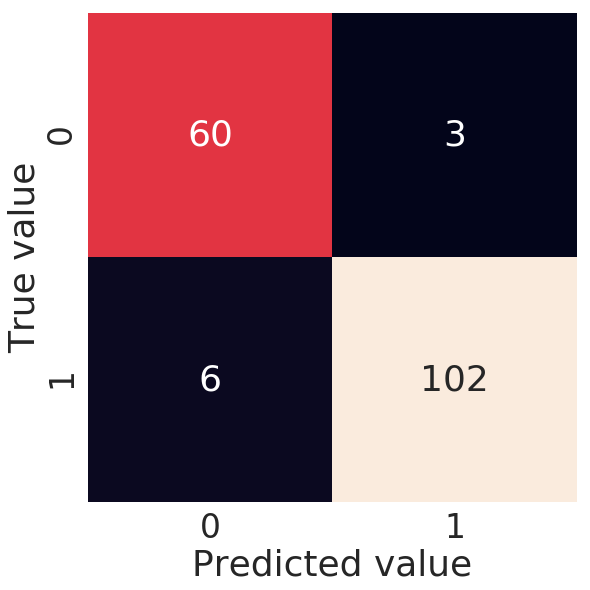

```python
# Evaluate the model with a confusion matrix
mat = confusion_matrix(y_test, y_pred)
plt.figure(figsize=(9, 9))
sns.heatmap(mat, square=True, annot=True, cbar=False, fmt='g')
plt.xlabel('Predicted value')
plt.ylabel('True value')
```